# Lab 4

Cassandra Richardson

2/15/2022

# 1. Inspect the item responses (e.g., with graphs or by summarizing distinct values). Is there anything unusual?

```r
#View(green_data)
#View(dictionary)
```

## Through looking at the scales in the dictionary, I realized that some of the variables are coded as -1, meaning that they will need to be reverse-coded before conducting analyses.

```r
reversed <- c("green2", "comp6", "comp7", "comp8", "comp9", "comp10", "intel7", "intel8", "intel9", "intel10", "open7", "open8", "open9", "open10")

green_data_fix <- green_data |>
  mutate_all(na_if, -99)

green_data_recoded <- green_data_fix |>
  mutate(across(
    all_of(reversed),
    \(x) recode(x, "5" = 1, "4" = 2, "3" = 3, "2" = 4, "1" = 5, "-99" = NA_real_)))

View(green_data_recoded)
```

# 2. Compute total scores for the four scales.

```r
summary(green_data_recoded)
```

```
##       id                green1          green2         green3
##  Length:373         Min.   :1.000   Min.   :1.00   Min.   :1.000
##  Class :character   1st Qu.:3.000   1st Qu.:2.00   1st Qu.:3.000
##  Mode  :character   Median :4.000   Median :3.00   Median :4.000
##                     Mean   :3.476   Mean   :3.07   Mean   :3.797
##                     3rd Qu.:4.000   3rd Qu.:4.00   3rd Qu.:4.000
##                     Max.   :5.000   Max.   :5.00   Max.   :5.000
##                     NA's   :58      NA's   :58     NA's   :58
##      green4          green5          comp1           comp2
##  Min.   :1.000   Min.   :1.000   Min.   :1.000   Min.   :1.000
##  1st Qu.:3.000   1st Qu.:2.000   1st Qu.:4.000   1st Qu.:4.000
##  Median :3.000   Median :3.000   Median :4.000   Median :4.000
##  Mean   :3.238   Mean   :2.835   Mean   :4.007   Mean   :4.051
##  3rd Qu.:4.000   3rd Qu.:4.000   3rd Qu.:4.000   3rd Qu.:4.750
##  Max.   :5.000   Max.   :5.000   Max.   :5.000   Max.   :5.000
##  NA's   :58      NA's   :58      NA's   :87      NA's   :79
##      comp3           comp4           comp5           comp6
##  Min.   :1.000   Min.   :1.000   Min.   :1.000   Min.   :1.000
##  1st Qu.:4.000   1st Qu.:4.000   1st Qu.:4.000   1st Qu.:3.000
##  Median :4.000   Median :4.000   Median :4.000   Median :4.000
##  Mean   :4.267   Mean   :4.049   Mean   :4.042   Mean   :3.839
##  3rd Qu.:5.000   3rd Qu.:4.000   3rd Qu.:4.000   3rd Qu.:4.000
##  Max.   :5.000   Max.   :5.000   Max.   :5.000   Max.   :5.000
##  NA's   :77      NA's   :86      NA's   :90      NA's   :81
##      comp7           comp8           comp9           comp10
##  Min.   :1.000   Min.   :1.000   Min.   :1.000   Min.   :1.000
##  1st Qu.:3.000   1st Qu.:4.000   1st Qu.:4.000   1st Qu.:4.000
##  Median :4.000   Median :4.000   Median :4.000   Median :4.000
##  Mean   :3.808   Mean   :3.904   Mean   :3.947   Mean   :4.067
##  3rd Qu.:4.000   3rd Qu.:4.000   3rd Qu.:4.000   3rd Qu.:5.000
##  Max.   :5.000   Max.   :5.000   Max.   :5.000   Max.   :5.000
##  NA's   :87      NA's   :91      NA's   :91      NA's   :90
##      intel1          intel2          intel3          intel4
##  Min.   :1.000   Min.   :1.000   Min.   :1.000   Min.   :1.000
##  1st Qu.:3.000   1st Qu.:3.000   1st Qu.:3.000   1st Qu.:3.000
##  Median :4.000   Median :4.000   Median :4.000   Median :4.000
##  Mean   :3.728   Mean   :3.699   Mean   :3.537   Mean   :3.375
##  3rd Qu.:4.000   3rd Qu.:4.000   3rd Qu.:4.000   3rd Qu.:4.000
##  Max.   :5.000   Max.   :5.000   Max.   :5.000   Max.   :5.000
##  NA's   :79      NA's   :91      NA's   :88      NA's   :90
```

[output cut: 17 more lines]

```
##  Min.   :1.000   Min.   :1.00   Min.   :1.00   Min.   :1.000   Min.   :1.000
##  1st Qu.:3.000   1st Qu.:3.00   1st Qu.:3.00   1st Qu.:3.000   1st Qu.:2.000
##  Median :4.000   Median :4.00   Median :4.00   Median :4.000   Median :3.000
##  Mean   :3.749   Mean   :3.92   Mean   :3.83   Mean   :3.592   Mean   :3.017
##  3rd Qu.:4.000   3rd Qu.:5.00   3rd Qu.:4.00   3rd Qu.:4.000   3rd Qu.:4.000
##  Max.   :5.000   Max.   :5.00   Max.   :5.00   Max.   :5.000   Max.   :5.000
##  NA's   :90      NA's   :86     NA's   :90     NA's   :86      NA's   :87
##      open8           open9           open10        student
##  Min.   :1.000   Min.   :1.000   Min.   :1.00   Min.   :1.000
##  1st Qu.:3.000   1st Qu.:2.000   1st Qu.:2.00   1st Qu.:1.000
##  Median :4.000   Median :4.000   Median :4.00   Median :2.000
##  Mean   :3.401   Mean   :3.432   Mean   :3.28   Mean   :1.671
##  3rd Qu.:4.000   3rd Qu.:4.000   3rd Qu.:4.00   3rd Qu.:2.000
##  Max.   :5.000   Max.   :5.000   Max.   :5.00   Max.   :2.000
##  NA's   :84      NA's   :77      NA's   :91     NA's   :96
```

```r
green_total_scores <- green_data_recoded |>
  rowwise() |>
  mutate(
    id = id,
    green_total = mean(c_across(green1:green5), na.rm = T),
    compassion_total = mean(c_across(comp1:comp10), na.rm = T),
    openness_total = mean(c_across(open1:open10), na.rm = T),
    intel_total = mean(c_across(intel1:intel10), na.rm = T),
    .before = everything())
```

# 3. Rescale variables to be 0-100 instead of original scales. Name these variables *_pomp

```r
green_data_rescaled <- green_total_scores |>
  mutate(
    across(green_total:intel_total,
    \(x) 100 * (x-1)/(5-1),
    .names = "{.col}_pomp"),
    .before = everything())
```

# 4. Make plots for the distributions of the 4 pomp-scored variables

## Histogram for total score on green reputation:

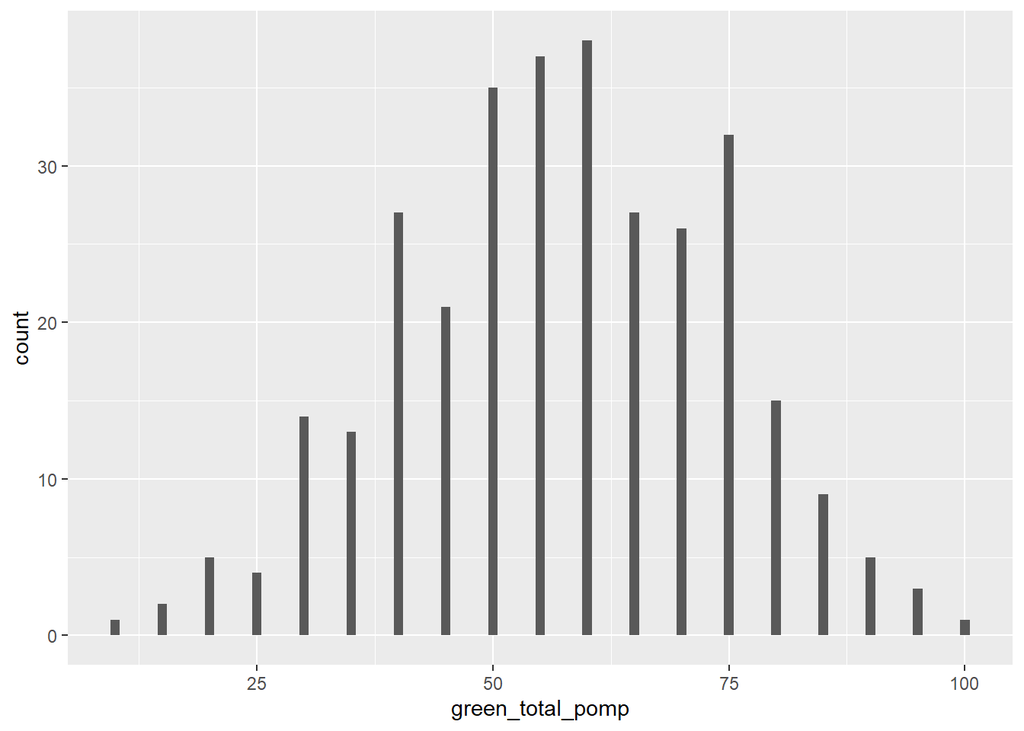

```r
ggplot(green_data_rescaled) +
  aes (x = green_total_pomp) +
  geom_histogram(binwidth = 1)
```

## Histogram for total score on compassion:

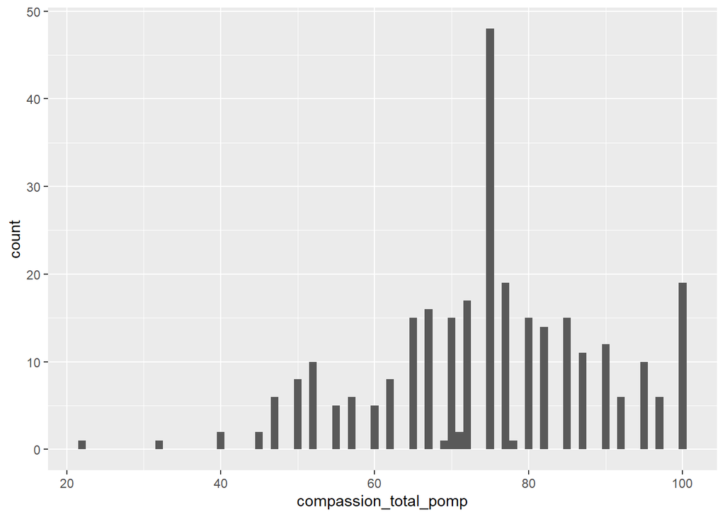

```r
ggplot(green_data_rescaled) +
  aes (x = compassion_total_pomp) +
  geom_histogram(binwidth = 1)
```

## Histogram for total score on openness to experiences:

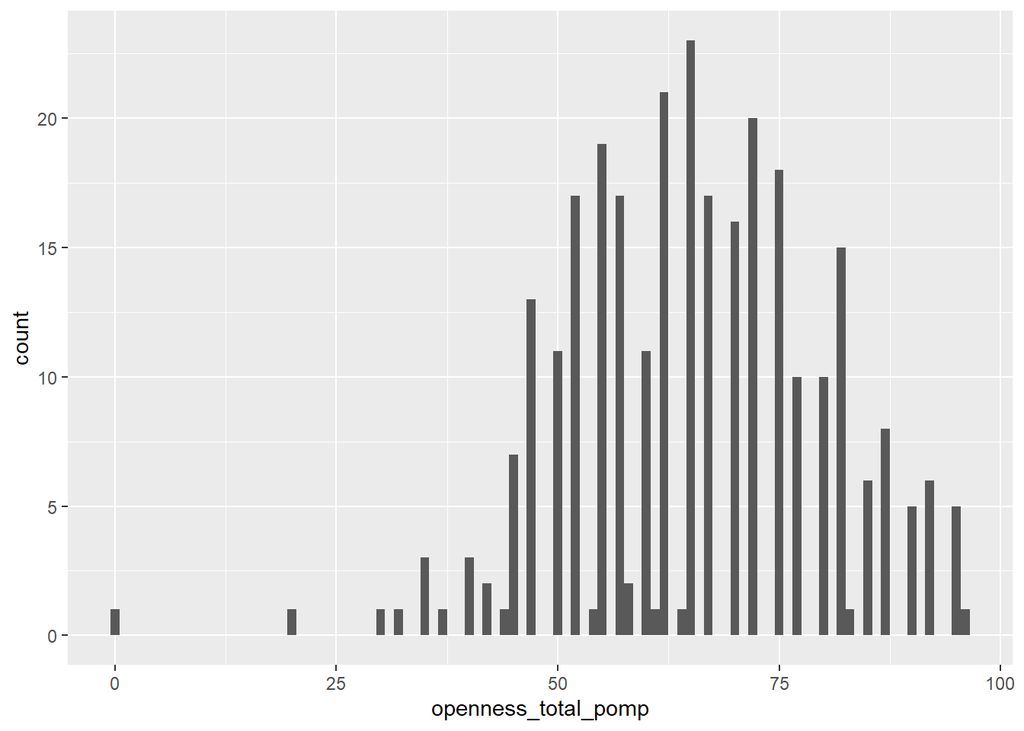

```r
ggplot(green_data_rescaled) +
  aes (x = openness_total_pomp) +
  geom_histogram(binwidth = 1)
```

## Histogram for total score on intellectual curiosity:

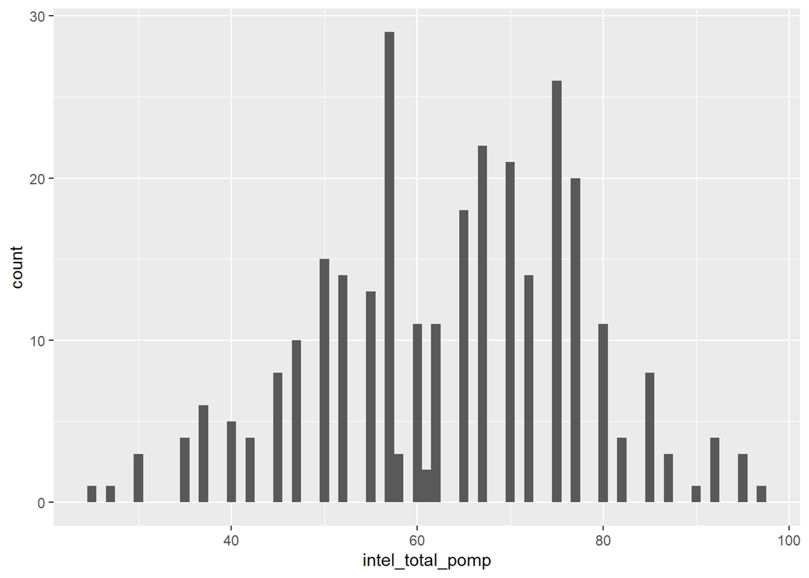

```r
ggplot(green_data_rescaled) +
  aes (x = intel_total_pomp) +
  geom_histogram(binwidth = 1)
```

# 5. Make scatterplots showing the relationship between green reputation and each personality trait. Include a trend line for students and non-students. What do these plots show?

## Scatterplot for green reputation and compassion:

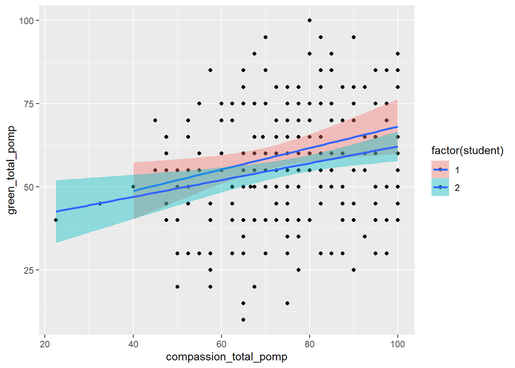

```r
green_data_rescaled |>
  filter(!is.na(student)) |>
ggplot() +
  aes(x = compassion_total_pomp, y = green_total_pomp,
       fill = factor(student)) +
  geom_point() +
  geom_smooth(method = "lm")
```

## Scatterplot for green reputation and openness:

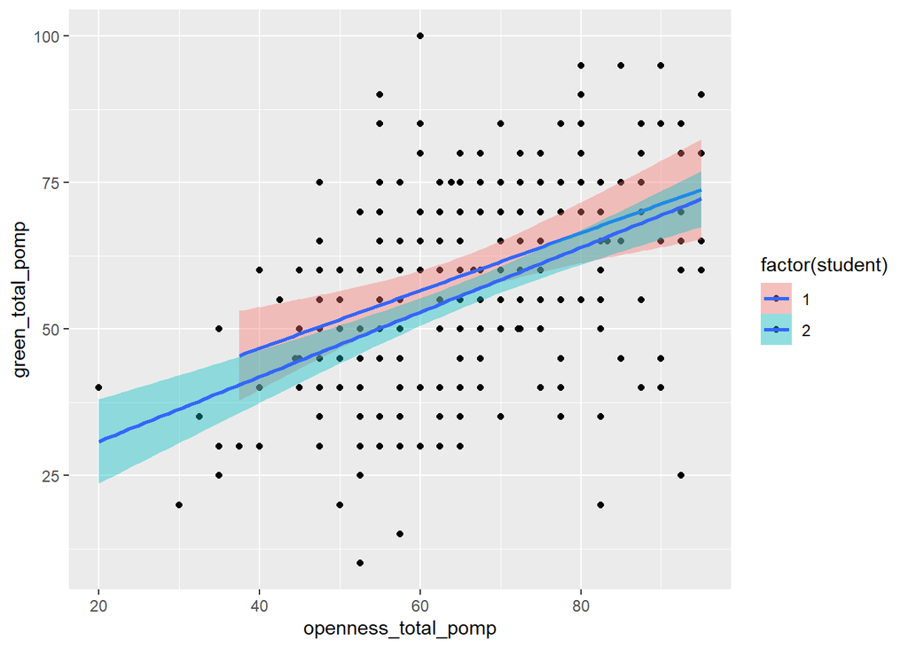

```r
green_data_rescaled |>
  filter(!is.na(student)) |>
ggplot() +
  aes(x = openness_total_pomp, y = green_total_pomp,
       fill = factor(student)) +
  geom_point() +
  geom_smooth(method = "lm")
```